# Cognateness, frequency, and vocabulary size

An interactive account of bilingual lexical acquisition

Gonzalo Garcia-Castro

gongarciacastro@gmail.com

Universitat Pompeu Fabra

Daniela S. Ávila-Varela

Universidade de Lisboa

Ignacio Castillejo

Universidad Autónoma de Madrid

Núria Sebastian-Galles

Universitat Pompeu Fabra

## Example slide

### This is a subtitle

Before we dive a bit deeper, here is a simple example of the [clean theme](https://github.com/grantmcdermott/quarto-revealjs-clean) in action.

- No pictures or anything fancy. Just text for the moment.

Next, we’ll take a brief tour of some theme components.

- We’ll use the same basic structure as the [original LaTeX slides](https://raw.githack.com/kylebutts/templates/master/latex-slides/auxiliary/slides.pdf).
- Note that the [*full suite*](https://quarto.org/docs/presentations/revealjs/) of Reveal.js features are available for this Quarto implementation, even if we don’t cover everything here.

## Before you proceed…

### Requirements for the coding examples in this demo

**R libraries**

While the clean theme is language agnostic, we will use several R coding examples in this demo to highlight some advanced theme features.

You will need the following libraries if you’d like to render the template “as-is”:

```r
install.packages(c("modelsummary", "gt", "fixest", "pdftools", "tinytex", "threejs"))
```

**TinyTex**

While Revealjs presentations are HTML format, we will show an example of how to embed LaTeX tables as images. This requires a working Tex distribution, of which TinyTex provides by far the easiest and lightest integration with Quarto. More details [here](https://quarto.org/docs/output-formats/pdf-engine.html).

```bash
quarto install tinytex
```

# Components

## Components

### Ordered and Unordered Lists

Here we have an unordered list.

- first item
  - sub-item
- second item

And next we have an ordered one.

1. first item
   1. sub-item
2. second item

## Components

### Alerts & Cross-refs

To emphasize specific words or text, you can:

- Use the default `.alert` class, e.g. important note.
- Use the `.fg` class for custom colour, e.g. important note.
- Use the `.bg` class for custom background, e.g. important note.

## Components

### Citations

Citations follow the standard [Quarto format](https://quarto.org/docs/authoring/footnotes-and-citations.html#citations) and be sourced from BibLaTex, BibTeX, or CLS files. For example:

- Topic 1: Spatial Frictions (Fajgelbaum et al. 2018; Hsieh and Moretti 2019; Moretti 2011)
- Topic 2: Blah (Suárez Serrato and Zidar 2016)

## Components

### Blocks

Quarto provides [dedicated environments](https://quarto.org/docs/authoring/cross-references.html#theorems-and-proofs) for theorems, lemmas, and so forth.

But in presentation format, it’s arguably more effective just to use a [Callout Block](https://quarto.org/docs/authoring/callouts.html).

**Regression Specification**

The main specification is as follows:

$$y_{it} = X_{it} \beta + \mu_i + \varepsilon_{it}$$

## Components

### Multicolumn I: Text only

Here is a long sentence that will wrap onto the next line as it hits the column width, and continuing on this way until it stops.

Some other text in another column.

A second paragraph.

Multicolumn support is very flexible and we can continue with a single full span column in the same slide.

## Components

### Multicolumn II: Text and figures

[figure not shown]

- A point about the figure that is potentially important.
- Another point about the figure that is also potentially important.

Note that sub- and multi-panel figures are also natively supported by Quarto. See [here](https://quarto.org/docs/authoring/figures.html#subfigures).

## Components

### Multicolumn III: Code and output

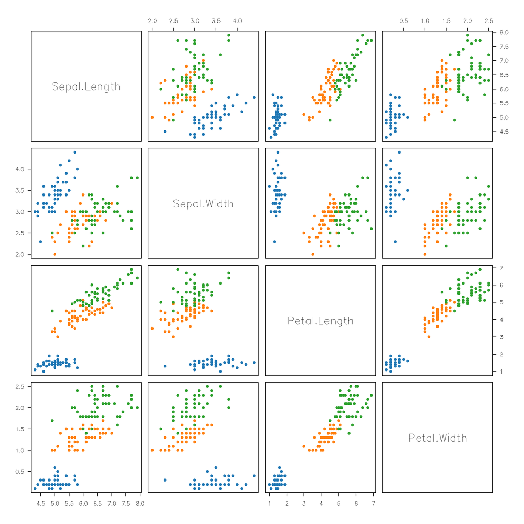

Figure 1: Pairwise scatterplot

```r
palette("Classic Tableau")

par(
  family = "HersheySans",
  las = 1, pch = 19, cex = 1.5
)

pairs(
  iris[,1:4],
  col=iris$Species
)
```

# Tables

## Tables

### Regression example

Quarto offers excellent [table support](https://quarto.org/docs/authoring/tables.html), with further customization via user libraries. Let’s illustrate with a regression example:

```r
library(fixest)

mods = feols(
  rating ~ complaints + privileges + learning + csw0(raises + critical) + advance,
  data = attitude
)

dict = c("rating"     = "Overall Rating",
         "complaints" = "Handling of Complaints",
         "privileges" = "No Special Priviledges",
         "learning"   = "Opportunity to Learn",
         "raises"     = "Performance-Based Raises",
         "critical"   = "Too Critical",
         "advance"    = "Advancement")
```

## Regression table

### modelsummary

If you use `modelsummary` with this Quarto theme, we advise setting the `gt` backend for a cleaner aesthetic. More details [here](https://vincentarelbundock.github.io/modelsummary/articles/appearance.html).

```r
library(modelsummary)
options(modelsummary_factory_default = "gt")

modelsummary(
  setNames(mods, c("(1)", "(2)")),
  coef_map = dict, stars = TRUE,
  gof_omit = "Adj|IC|F|Log|RMSE"
  ) |>
  gt::tab_spanner(
    label = "Dependent variable: Overall Rating",
    columns = 2:3
  )
```

## Regression table

|  | Dependent variable: Overall Rating (1) | Dependent variable: Overall Rating (2) |
| --- | --- | --- |
| Handling of Complaints | 0.653*** | 0.613*** |
|  | (0.131) | (0.161) |
| No Special Priviledges | -0.077 | -0.073 |
|  | (0.131) | (0.136) |
| Opportunity to Learn | 0.324+ | 0.320+ |
|  | (0.157) | (0.169) |
| Performance-Based Raises |  | 0.082 |
|  |  | (0.221) |
| Too Critical |  | 0.038 |
|  |  | (0.147) |
| Advancement | -0.172 | -0.217 |
|  | (0.149) | (0.178) |
| Num.Obs. | 30 | 30 |
| R2 | 0.729 | 0.733 |
| Std.Errors | IID | IID |

+ p < 0.1, * p < 0.05, ** p < 0.01, *** p < 0.001

## Regression table

### etable

`fixest`’s powerful native tabling functions were designed for LaTeX output. But we can use the `markdown = TRUE` option to make them work with this theme too. (Details [here](https://lrberge.github.io/fixest/articles/etable_new_features.html).) Quick notes:

- Install the `tinytex` & `pdftools` packages first.
- Set the R chunk option `output: asis`.

````markdown
```{r}
#| output: asis

setFixest_etable(markdown = TRUE, drop = "Constant")
setFixest_dict(dict)

etable(mods, highlight = .("se" = "complaints"))
```
````

# Figures

## Figure

[figure not shown]

## Figure

### Full-size Figures

You can use the `{.background-image}` container environment to completely fill the slide background with an image.

Ideally, your figure will be the same aspect ratio as the screen that you’re presenting on.

- This can be a bit tricky because of the dynamic nature of Reveal.js / HTML. But its probably something close to 16:9.
- Aspect ratio can also matter for a regular full-frame images (previous slide).

## Interactive plots

[interactive chart not shown]

*Note: Simple flight data example using `threejs`. There are many interactive plotting options beyond this. (More [details](https://quarto.org/docs/interactive/).)*

# Summary

## Summary

### A minimal and elegant presentation theme

The Quarto Revealjs clean theme is intended as a minimal and elegant presention theme.

We have highlighted some theme-specific components. But all of the regular Revealjs functionality is supported (chalkboard, etc.)

Install the theme:

```bash
quarto install extension grantmcdermott/quarto-revealjs-clean
```

Use these demo slides as a template:

```bash
quarto use template grantmcdermott/quarto-revealjs-clean-demo
```

## References

Fajgelbaum, Pablo D, Eduardo Morales, Juan Carlos Suarez Serrato, and Owen Zidar. 2018. “State Taxes and Spatial Misallocation,” 90.

Hsieh, Chang-Tai, and Enrico Moretti. 2019. “Housing Constraints and Spatial Misallocation.” *American Economic Journal: Macroeconomics* 11 (2): 39.

Moretti, Enrico. 2011. “Local Labor Markets.” In *Handbook of Labor Economics*. Vol. 4. Elsevier.

Suárez Serrato, Juan Carlos, and Owen Zidar. 2016. “Who Benefits from State Corporate Tax Cuts? A Local Labor Markets Approach with Heterogeneous Firms.” *American Economic Review* 106 (9).

## Appendix

Table 1: Summary of the base R `attitude` dataset

|  | Unique (#) | Missing (%) | Mean | SD | Min | Median | Max |
| --- | --- | --- | --- | --- | --- | --- | --- |
| rating | 22 | 0 | 64.6 | 12.2 | 40.0 | 65.5 | 85.0 |
| complaints | 23 | 0 | 66.6 | 13.3 | 37.0 | 65.0 | 90.0 |
| privileges | 24 | 0 | 53.1 | 12.2 | 30.0 | 51.5 | 83.0 |
| learning | 23 | 0 | 56.4 | 11.7 | 34.0 | 56.5 | 75.0 |
| raises | 21 | 0 | 64.6 | 10.4 | 43.0 | 63.5 | 88.0 |
| critical | 21 | 0 | 74.8 | 9.9 | 49.0 | 77.5 | 92.0 |
| advance | 20 | 0 | 42.9 | 10.3 | 25.0 | 41.0 | 72.0 |

Back to main